# Gamma

Wenhui Wu

2022-10-25

## Introduction

近年来，基于退化的可靠性技术在模型、方法和应用等方面得到快速发展。其中，在**基于退化的可靠性模型**方面，以随机过程理论为基础，根据工程需要，并考虑模型的简明性、实用性和适用性，已经提出了多种类型的模型，包括：

1. 退化轨道模型（如 Paris 模型、随机斜率/截距模型、幂律模型、反应论模型）
2. 基于 Wiener 过程的模型
3. 基于 Gamma 过程的模型
4. 累积损伤模型(主要是基于混合 Poisson 过程的模型）
5. 更为一般的纯跳过程模型（如Levy.过程模利）和扩散过程模型（如随机微分方程模型）等。

在基于退化的可靠性建模方法，以数理统计理论为基础，针对模型和退化数据的类型，研究**矩估计、极大似估计及 EM 算法、Bayes 估计及 MCMC算法、基于滤波的状态估计方法**，以及**非参数和半参数方法**等，解决模型辨识和修正问题;

采用**似然比检验、Bayes 因子分析**等方法进行模型验证;

采用**均方误差（MSE）、Akaike 信息准则(AIC)、Bayes 信息准则(BIC)、偏差信息准则(DIC)**等进行模型优良性检验。

在基于退化的可靠性技术应用方面，针对**机械零部件（如轴承、润滑系统）、半导体器件（如功率MOS器件）、机电部件（如感应电动机）、光电器件(如太阳电池、激光器、LED)、电子器件（如电容、蓄电池）**等的退化失效过程，开展**退化过程建模、可靠性评估、剩余寿命预测、可靠性试验设计**：特别是加速退化试验方案设计的研究。

## 4. Gamma退化过程模型

Gamma 过程描述的退化过程是严格单调非负的，并且Gamma 过程是纯跳过程，其样本路径不连续，既可描述连续的微小冲击导致的缓慢退化，也可以描述大的冲击导致的大的损伤。 当产品的退化过程是严格单调非负时, Wiener 过程不再适用。Gamma 过程具有独立非负增量,可以对该类退化过程进行建模。

### 4.1 简单Gamma 退化过程

称连续时间随机过程 $\{X(t), t \geqslant 0\}$ 是平稳 Gamma 过程 ${ }^{[2]}$, 若它满足以下性质:

1. $X(0)=0$ 以概率 1 成立。
2. $X(t)$ 具有平稳独立增量。
3. 对任意 $t \geqslant 0$ 和 $\Delta t, X(t+\Delta t)-X(t) \sim G a(\alpha \Delta t, \beta)$ 。

   其中 $G a(\alpha, \beta)$ 是形状参数为 $\alpha>0$ 、尺度参数为 $\beta>0$ 的 Gamma 分布, 分布密度函数为
   $$f(x \mid \alpha, \beta)=\frac{1}{\Gamma(\alpha) \beta^\alpha}
   \alpha^{\alpha-1} \mathrm{e}^{-x / \beta} I_{(0, \infty)}(x)$$
   并且 $\{X(t), t \geqslant 0\}$ 称为形状参数为 $\alpha>0$ 、尺度参数为 $\beta>0$ 的平稳 Gamma 过程。

**产品寿命**

因为Gamma 过程的退化是单调递增的，即$X(t) \sim Ga(\alpha t,\beta)$ ,因此**产品寿命**的分布可以直接通过退化量的转换获得。当给定产品退化失效阈值 $\ell$ 时，产品寿命 $T$ 的CDF和PDF为

$$\begin{aligned}
{F}_{{T}}(t) &={P}({T} \leqslant {t})={P}({X}({t}) \geqslant \ell)
\\
&=\int_{\ell}^{\infty} \frac{1}{\Gamma(\alpha {t}) \beta^{\alpha
{t}}} {x}^{\alpha {t}-1} \mathrm{e}^{-\frac{{x}}{\beta}} {dx} \\
&=\frac{1}{\Gamma(\alpha {t})} \int_{\frac{\ell}{\beta}}^{\infty}
\xi^{\alpha {t}-1} \mathrm{e}^{-\xi} {d} \xi ,\\
{f}_{{T}}(t) &=\frac{{d}}{{dt}} \frac{\Gamma(\alpha {t}, 1 /
\beta)}{\Gamma(\alpha {t})} \\
&=\frac{\alpha}{\Gamma(\alpha {t})} \int_0^{\nu / \beta}\left[\ln
(\xi)-\frac{\Gamma^{\prime}(\alpha {t})}{\Gamma(\alpha {t})}\right]
\xi^{\alpha {t}-1} \mathrm{e}^{-\xi} {d} \xi.
\end{aligned}$$

由于${f}_{{T}}({t})$ 相当复杂，因此一般用B-S分布来逼近：

$${F}(t ;
\ell)=\Phi\left[\frac{1}{{v}}\left(\sqrt{\frac{{t}}{{u}}}-\sqrt{\frac{{u}}{{t}}}\right)\right],
\quad {t}>0.$$
其中，$\Phi(\cdot)$ 为标准正态分布，$v=\sqrt{\frac{\beta}{\ell}}, u=\frac{\ell}{\beta \alpha}$. 相应的 PDF 为
$${f}(t ; \ell)=\frac{1}{2 \sqrt{2 \pi}
{uv}}\left[\left(\frac{{u}}{{t}}\right)^{\frac{1}{2}}+\left(\frac{{u}}{{t}}\right)^{\frac{3}{2}}\right]
\exp \left[-\frac{1}{2
{v}^2}\left(\frac{{t}}{{u}}-2+\frac{{u}}{{t}}\right)\right], {t}>0.$$

**剩余寿命**

根据Gamma 过程的增量独立性，可以得到剩余寿命的分布
$$\begin{aligned}
{F}(t \mid s) &={P}\left({T} \leqslant t \mid {X}(s)={x}_{s}\right)
\\
&={P}\left(X(t)-X(s) \geqslant \ell-x_{s}\right) \\
&=\frac{\Gamma\left(\alpha(t-s),\left(\ell-x_{s}\right) /
\beta\right)}{\Gamma(\alpha(t-s))} .
\end{aligned}$$
这与将失效阈值由 $\ell$ 变为 $\ell-{x_s}$ 、时间 $t$ 变为 $t-s$ 情形的寿命分布是一样的. 因此，在给定当前状态情况下，可以按照类似的途径更新剩余寿命.

```r
library(ggplot2)
library(tidyverse)
library(viridis)
library(dplyr)
```

#### 4.1.1 数据模拟产生

```r
# 数据模拟产生
sim_dat = function(group = 6, t = 1:200, para = c(4,2)){
  # para 指 alpha,beta
  # epoch 指测量次数， group 指组数
  delta_t = diff(t)
  epoch = length(delta_t)
  dat = dat_unit = matrix(NA,epoch,group+1)
  dat[,1] = dat_unit[,1] = seq(1,epoch)
  # dat_unit = numeric()
  for(i in 1:group){
    for(j in 1:epoch) {
      dat_unit[j,i+1] = rgamma(1,para[1]*delta_t[j],para[2])
      dat[,i+1] = cumsum(dat_unit[,i+1])
    }
  }
  dat = data.frame(dat)
  dat1 = rbind(rep(0,group+1),dat) # 加入初始值绘制点
  colnames(dat1) = c("Time",paste(1:group,sep=''))

  dat_unit = data.frame(dat_unit)
  dat_unit1 = rbind(rep(0,group+1),dat_unit) # 加入初始值绘制点
  colnames(dat_unit1) = c("Time",paste(1:group,sep=''))

  return(list(dat1,dat_unit1)) #dat1是退化量,data_unit1是退化增量
}
```

绘制退化路径图

```r
# 绘制退化路径图
plot_path = function(data = dat1){
    # 画图
  p = data %>% pivot_longer(paste(1:group),
                       names_to = "Group",
                       values_to = "y") %>%
    ggplot(aes(Time,y,color = Group)) +
    geom_line() +
    scale_color_viridis(discrete = T) +
    ylab("Degradation") #+
    #theme_bw() +
    #theme(panel.grid = element_blank())
  print(p)
}
```

```r
group = 6
t = 1:200
para = c(4,2)
dat = sim_dat(group = group, t = t, para = para)
knitr::kable(head(dat[[1]])) #print table
```

| Time | 1 | 2 | 3 | 4 | 5 | 6 |
| --- | --- | --- | --- | --- | --- | --- |
| 0 | 0.000000 | 0.000000 | 0.0000000 | 0.0000000 | 0.000000 | 0.000000 |
| 1 | 1.446802 | 1.372143 | 0.6070372 | 0.8603048 | 2.954390 | 1.227243 |
| 2 | 2.359555 | 3.662892 | 2.4677444 | 1.7524944 | 5.224625 | 3.961899 |
| 3 | 3.372603 | 7.056622 | 4.7164627 | 3.4005598 | 7.705829 | 7.965865 |
| 4 | 4.234004 | 7.528841 | 6.0812819 | 5.8599677 | 8.801938 | 10.465259 |
| 5 | 8.000965 | 10.012818 | 9.4866227 | 7.2364805 | 9.424813 | 13.412937 |

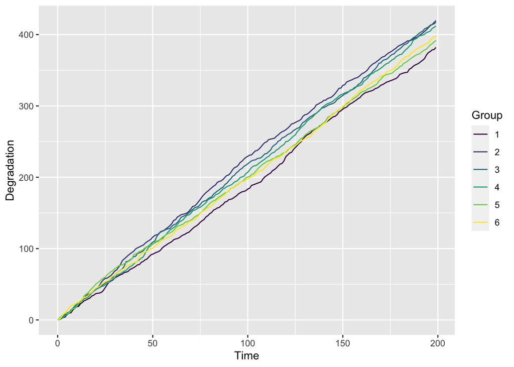

```r
plot_path(dat[[1]]) #print path plot
```

#### 4.1.2 统计推断

假设共有 ${n}$ 个样品进行性能退化试验. 对于样品 $i$, 初始时刻 $t_0$ 性能退化量为 $X_{i 0}=0$, 在时刻 $t_1, \cdots, t_{m_i}$ 测量产品的性能退化量, 得到其测量值为 $X_{i 1}, \cdots, X_{i m_i}$. 记 $\Delta x_{i j}=X_{i j}-X_{i(j-1)}$ 是样品 $i$ 在时刻 $t_{j-1}$ 和 $t_j$ 之间的性能退化量, 由 Gamma 过程的独立增量性得到$\Delta X(t) \sim Ga(\alpha \Delta t_{ij},\beta)$。

##### 4.1.2.1 矩估计

令 $R_{i j}=\Delta X_{i j} / \Delta t_{i j}$, 则诸 $R_{i j}, j=1,2, \cdots, m_i, i=1,2, \cdots, n$ 服从形状参数为 $\alpha$ 、尺度参数为 $\beta$ 的 Gamma 分布, 且相互独立(根据 Gamma 过程独立增量特性, 以及各样品退化过程的独立性)。记 $M=\sum_{i=1}^n m_i$, 样本均值和样本方差为
$$\begin{align}
\bar{R}& =\frac{1}{M} \sum_{i=1}^n \sum_{j=1}^{m_i} R_{i j} \\
S_R^2 & =\frac{1}{M-1} \sum_{i=1}^n \sum_{j=1}^{m_i}\left[R_{i
j}-\bar{R}\right]^2
\end{align}$$
易知
$$\begin{aligned}
E[\bar{R}] &=\alpha \beta \\
Var[\bar{R}]&=\frac{1}{M^2} \alpha \beta^2 \sum_{i=1}^n
\sum_{j=1}^{m_i}\left[1 / \Delta t_{i j}\right]\\
\end{aligned}$$
所以，

$$\begin{aligned}
E\left[S_R^2\right]&=\frac{1}{M-1} \sum_{i=1}^n \sum_{j=1}^{m_i}
E\left[R_{i j}-\bar{R}\right]^2\\
&=\frac{1}{M-1} \sum_{i=1}^n \sum_{j=1}^{m_i} E\left[R_{i j}-\alpha
\beta-(\bar{R}-\alpha \beta)\right]^2 \\
&=\frac{1}{M-1} \sum_{i=1}^n \sum_{j=1}^{m_i}\left\{Var\left[R_{i
j}\right]^2-\frac{2}{m_i} Var\left[R_{i j}\right]+Var[\bar{R}]\right\}
\\
&=\frac{1}{M-1} \alpha \beta^2 \sum_{i=1}^n
\sum_{j=1}^{m_i}\left[\frac{1}{\Delta t_{i j}}\right]
\end{aligned}$$
将待估参数和样本矩联系起来, 即令
$$\left\{\begin{array}{l}
\alpha \beta=\bar{R} \\
\alpha \beta^2=M S_R^2 / \sum_{i=1}^n \sum_{j=1}^{m_i}\left[1 / \Delta
t_{i j}\right]
\end{array}\right.$$
可得如下矩估计:
$$\begin{gathered}
\hat{\alpha}=\frac{\sum_{i=1}^n \sum_{j=1}^{m_i}\left[1 / \Delta t_{i
j}\right] \bar{R}^2}{M S_R^2} \\
\hat{\beta}=\frac{M S_R^2}{\sum_{i=1}^n \sum_{j=1}^{m_i}\left[1 / \Delta
t_{i j}\right] \bar{R}}
\end{gathered}$$

上述矩估计方法是基于退化速率的，金光还给出了基于退化量的矩估计（详见P128）,注意到当测量间隔都相同时，两个矩估计方法相同。

```r
gamma_moment = function(data_unit, group , t ){

  # 每组测量次数相同
  delta_t = diff(t)
  M = group*max(t)
  Rij = data_unit/delta_t
  Rbar = sum(Rij)/M
  SR2 = sum((Rij-Rbar)^2)/(M-1)
  MSR2 = M*SR2
  tt = group*sum(1/delta_t)
  moment_alp = Rbar^2*tt/MSR2
  moment_beta = MSR2/(tt*Rbar)

  moment_par = c(moment_alp,moment_beta)
  return(moment_par)

}
# 这里算出来beta的矩估计跟真值差距很大
# 注意如果用模拟数据产生的话，只保留增量数据,也要去掉第一行的0
# ？ 前面加上这么多只是为了画图好看，是不是可以删掉这些东西
increment = dat[[2]]
increment = increment[-1,2:7]
degradation = dat[[1]]
degradation = degradation[-1,2:7]

moment_par = gamma_moment(data_unit = increment, group = 6, t = 1:200)
moment_par
```

```
## [1] 4.0759411 0.4948685
```

##### 4.1.2.2 极大似然估计

由 Gamma 过程独立增量特性, 以及
$$\Delta X_{i j} \sim G a\left(\alpha \Delta t_{i j},
\beta\right)=\frac{\left(\Delta x_{i j} / \beta\right)^{\alpha \Delta
t_{i j}-1}}{\beta \Gamma\left(\alpha \Delta t_{i j}\right)}
\mathrm{e}^{-\Delta x_{i j} / \beta}$$
可以获得对数似然函数为
$$l(\alpha, \beta)=\sum_{i=1}^n\left(\sum_{j=1}^{m_i}\left(\alpha \Delta
t_{i j}-1\right) \ln \Delta x_{i j}-\alpha t_{i m_i} \ln
\beta-\sum_{j=1}^{m_i} \ln \Gamma\left(\alpha \Delta t_{i
j}\right)-\frac{x_{i m_i}}{\beta}\right)$$
由极大似然估计原理, 令
$$\left\{\begin{array}{l}
\frac{\partial l}{\partial \alpha}=\sum_{i=1}^n \sum_{j=1}^{m_i} \Delta
t_{i j}\left(\ln x_{i j}-\psi\left(\alpha \Delta t_{i j}\right)-\ln
\beta\right)=0 \\
\frac{\partial l}{\partial \beta}=\sum_{i=1}^n\left(\frac{x_{i
m_i}}{\beta^2}-\frac{\alpha t_{i m_i}}{\beta}\right)=0
\end{array}\right.$$
式中 $\psi(u)$ 是 digamma 函数。
$$\begin{aligned}
&\hat{\beta}=\frac{\sum_{i=1}^n X_{i m_i}}{\alpha \sum_{i=1}^n t_{i
m_i}}\\
&\sum_{i=1}^n\left[\sum_{j=1}^{m_i} \Delta t_{i j} \ln \left(\Delta
x_{i j}\right)-t_{i m_i} \ln \frac{x_{i m_i}}{\alpha t_{i
m_i}}-\sum_{j=1}^{m_i} \Delta t_{i j} \psi\left(\alpha \Delta t_{i
j}\right)\right]=0
\end{aligned}$$

```r
library(BB)

gamma_alpmle = function(x, data_unit, data, t){
    #x is alpha
    delta_t = diff(t)
    l = sum(delta_t*log(data_unit))-sum(t*log(data/(x*t)))-sum(delta_t*digamma(x*delta_t))
    return(l)
}

startx = 1
mle_re = dfsane(startx,gamma_alpmle,data_unit = increment, data = degradation, t = 1:200,control=list(maxit=2500,trace = FALSE))

mle_re
```

```
## $par
## [1] 1.851994
##
## $residual
## [1] 1.360604e-09
##
## $fn.reduction
## [1] 73411.97
##
## $feval
## [1] 8
##
## $iter
## [1] 7
##
## $convergence
## [1] 0
##
## $message
## [1] "Successful convergence"
```

```r
mle_alp = mle_re$par
mle_beta = sum(increment)/(mle_alp*group*max(t))
mle_par = c(mle_alp,mle_beta)


# mle_re = uniroot(gamma_alpmle, data_unit = increment, data = degradation, t = 1:200, lower = 1, upper = 100, tol = 1e-15, maxiter = 10000)
#
# mle_alp = mle_re$root
# mle_beta = sum(increment)/(mle_alp*group*max(t))
# mle_par = c(mle_alp,mle_beta)
```

```r
## 可靠度计算
gamma_R = function(t, threshold,par){
  alp = par[1]
  beta = par[2]
  v = sqrt(beta/threshold)
  u = threshold/(alp*beta)
  R = 1-pnorm((sqrt(t/u)-sqrt(u/t))/v)
  return(R)
}
gamma_R(t = 70, threshold = 150,par = mle_par)
```

```
## [1] 0.7611893
```

```r
# plot(gamma_R(t = 1:300, threshold = 150,par = mle_par),type = "l")
```

##### 4.1.2.3 广义推断方法

- 伽马 + 随机过程

Wang, X. F., et al. (2021). “Degradation data analysis based on gamma process with random effects.” European Journal of Operational Research 292(3): 1200-1208.

- 伽马 + 加速寿命试验

Jiang, P. H., et al. (2019). “Inference for constant-stress accelerated degradation test based on Gamma process.” Applied Mathematical Modelling 67: 123-134.

### 4.2 含协变量影响及随机效应情形

随机效应反映个体差异的不确定性，协变量反映环境的影响。在基于 Gamma 过程的退化建模问题中, 随机效应通过混合尺度 Gamma 过程来描述。

- 尺度参数 $B$ 是服从 逆 Gamma 分布的随机变量, 即 $W=B^{-1} \sim G a\left(\delta, \gamma^{-1}\right)$; 在给定 $B=1 / w$ 的情况下, $X(t)$ 是 形状函数为 $\alpha(t)$ 、尺度参数为 $1 / w$ 的非平稳 Gamma 过程。
- 如果存在协变量效应, 假设协变量可以集成进入尺度参数, 从而尺度参数 $B$ 用 $B \xi(z)$ 代替, 这里 $z$ 表示协变量, $\xi(z)$ 表示协变量效应。

在这些假设下, 可以得到退化增量 $\Delta X_{i j}$ 的**联合分布密度**如下:
$$\begin{aligned}
&f\left(\Delta x_{i j}, j=1, \cdots, m_i, i=1, \cdots,
n\right)=\int\left\{\prod_{i=1}^n \prod_{j=1}^{m_i} g a\left(\Delta x_{i
j} ; w^{-1} \xi_{z_i}, \Delta \alpha_{i j}\right)\right\} g a\left(w ;
\gamma^{-1}, \delta\right) \mathrm{d} w \\
&=\prod_{i=1}^n\left[\frac{\Gamma\left(\delta+\alpha_{i
m_i}\right)}{\Gamma(\delta) \prod_{j=1}^{m_i} \Gamma\left(\Delta
\alpha_{i j}\right)} \frac{\left(\gamma \xi_{z_i}\right)^\delta
\prod_{j=1}^{m_i}\left(\Delta x_{i j}\right)^{\Delta \alpha_{i
j}-1}}{\left.\left(\gamma \xi_{z_i}+x_{i m_i}\right)^{\delta+\alpha_{i
m_i}}\right]}\right] \\
\end{aligned}$$
式中 $x_{i m_i}=\sum_{j=1}^{m_i} \Delta x_{i j}$ ; $\alpha_{i m_i}=\sum_{j=1}^{m_i} \Delta \alpha_{i j}$ ; $ _{z_i}=(z_i) $; $z_i$ 是样品$i$ 的协变量取值。

通过极大化上述似然函数, 即可得到参数的极大似然估计。当然, 由于此似然函数非常复杂, 一般需要采用数值解法, 如牛顿 - 拉夫逊算法、拟牛顿法等。

- 有些情况下需要估计个体的尺度参数 $\beta_i$ 。由于 $E\left[X_{i m_i} \mid B=\beta_i\right]=\beta_i \alpha_{i m_i}$, 因此一个有 效的估计是 $\tilde{\beta}_i=X_{i m_i} / \alpha_{i m_i}$ 。实际上, $\tilde{\beta}_i$ 是退化增量 $\Delta X_{i j}, j=1,2, \cdots, m_i$ 的最小方差线性无偏估计, 这由 $\Delta X_{i j} \mid \beta_i=\beta_i^2 \Delta \alpha_{i j}$ 可知。
- 另一种估计可由 $W=B^{-1}$ 与退化增量的联合分布得到, 这里对应的密度函数为 $\left\{\prod_{j=1}^{m_i} g a\left(\Delta x_{i j} ; w^{-1}, \Delta \alpha_{i j}\right)\right\} g a\left(w ; \gamma^{-1}, \delta\right)$, 从中可以得到给定 退化增量情况下 $W$ 的条件分布为 $G a\left\{\left(x_{i m_i}+\gamma\right)^{-1}, \alpha_{i m_i}+\delta\right\}$, 条件期望为
  $$E\left[W \mid \Delta x_{i 1}, \cdots, \Delta x_{i
  m_i}\right]=\left(\alpha_{i m_i}+\delta\right) /\left(x_{i
  m_i}+\gamma\right)$$
  将参数估计结果代人上式或上面的 $\tilde{\beta}_i$, 得到对应于个体产品的 $W$ 或 $B$ 的实现的估计。

除了需要估计随机效应分布, 有时还关心随机效应是否显著的假设检验问题(即是否确实存在随机效应或个体差异).

### 4.3 有测量误差情形

- 当测量误差显著时, 此时, 观测数据是被噪声污染的 Gamma 过程的样本路径。
- 设在时刻 $t_{i j}$ 的测量值为 $y_{i j}=x_{i j}+\varepsilon_{i j}$, 其中 $x_{i j}$ 是实际退化, $\varepsilon_{i j}$ 是正态独立随机变量, 均值为 0 , 方差为 $\sigma_e^2$ 。
- 注意到 $\Delta y_{i j}=\Delta x_{i j}+\varepsilon_{i j}-\varepsilon_{i, j-1}$, 因此 虽然 $\Delta x_{i j}$ 是独立的, 观测到的增量 $\Delta y_{i j}$ 不再是独立的, 这导致似然函数的构造变得复杂。

实际上, 对样品 $i$ 的观测数据, 有
$$\left(\begin{array}{c}
\Delta y_{i 1} \\
\Delta y_{i 2} \\
\vdots \\
\Delta y_{i m_i}
\end{array}\right)=\left(\begin{array}{c}
\Delta x_{i 1} \\
\Delta x_{i 2} \\
\vdots \\
\Delta x_{i m_i}
\end{array}\right)+\left[\begin{array}{cccc}
1 & & & \\
-1 & 1 & & \\
& \ddots & \ddots & \\
& & -1 & 1
\end{array}\right]\left(\begin{array}{c}
\varepsilon_{i 1} \\
\varepsilon_{i 2} \\
\vdots \\
\varepsilon_{i m_i}
\end{array}\right)$$
或者 $\Delta \boldsymbol{y}_i=\Delta \boldsymbol{x}_i+C \varepsilon_i=\Delta \boldsymbol{x}_i+\eta_i$, 其中 $\eta_i \sim N\left(0, \sigma^2 \Sigma\right)$, 而且
$$\sum=C C^{\prime}=\left[\begin{array}{ccccc}
1 & -1 & & & \\
-1 & 2 & -1 & & \\
& \ddots & \ddots & \ddots & \\
& & -1 & 2 & -1 \\
& & & -1 & 2
\end{array}\right]$$
也就是说, $\eta_{i 1}, \cdots, \eta_{i m_i}$ 并不是相互独立的。因此, 这时的似然函数难以解析求解, 一般 需要采用数值方法。

**更一般的情形**

下面考虑一种更加一般的情形, 并采用 MC 方法得到模型参数的估计。对实际退化进行观测, 观测值满足如下模型:
$$Y(t)=F(X(t))+\varepsilon$$
这里观测噪声 $\varepsilon \sim N\left(0, \sigma^2\right)$ 。显然, 有测量误 差是这里的特殊情形, 此时只要取 $F(t)=t$ 即可。在基于退化的可靠性建模问题中, 称 $X(t)$ 为直接退化量 (Direct Indicator), 而 $Y(t)$ 称为间接退化量 (Indirect Indicator)。下 面的计算过程假设 $F(X(t))=c X(t)^d$ 。

假设可以在 $t_1, t_2, \cdots, t_n$ 时刻进行观测, $n$ 是观测次数。 函数 $I_{\mathrm{obv}}(\cdot)$ 定义为
$$I_{\mathrm{obv}}(i)= \begin{cases}0, & x_i \text { 不可观测 } \\ 1,
& x_i \text { 可观测 }\end{cases}$$
用来表示一个观测量是直接退化量。第 $l$ 个可观测的直接退化量的观测时间指标记为 $k_l, l=1,2, \cdots, m$, 其中 $m$ 是观测的直接退化量的个数。显然 $I_{\mathrm{obv}}\left(k_l\right)=1, l=1,2, \cdots$, $m$ 。假设至少能够观测到一个直接退化量, 即 $m>0$ 。下面采用 EM 算法来解决参数估 计问题。 假设可观测的直接退化量 $x_{k_{1, m}}=\left\{x_{k_l}: l=1,2, \cdots, m\right\}$ 以及它们对应的间接退化量 $y_{k_{1, m}}=\left\{y_{k_l}: l=1,2, \cdots, m\right\}$, 则基于 $x_{k_1, m}$ 和 $y_{k_{1, m}}$ 的完整似然函数, 可以得到参数的一个极 大似然估计, 将该估计作为模型参数的初始值。

**EM算法**

在 $\mathrm{EM}$ 算法的 $\mathrm{E}$ 步, 需要估计对应于所有 $n$ 个时刻的可能观测数据的完整的似然 函数的期望。完整似然函数可以分为两个部分:
$$E\left[\ln \left(f\left(x_{1 ; n}, y_{1 ; n} \mid
\boldsymbol{\theta}\right)\right)\right]=E\left[\ln \left(f\left(x_{1 ;
n} \mid \boldsymbol{\theta}_1\right)\right)\right]+E\left[\ln
\left(f\left(y_{1 ; n} \mid \boldsymbol{\theta}_2, x_{1 ;
n}\right)\right)\right]$$
式中: 参数 $\boldsymbol{\theta} 、 \boldsymbol{\theta}_1$ 和 $\boldsymbol{\theta}_2$ 表示待估参数向量, 其中 $\boldsymbol{\theta}=(a, b, \beta, c, d, \boldsymbol{\sigma}), \boldsymbol{\theta}_1=(a, b, \boldsymbol{\beta}), \boldsymbol{\theta}_2=$ $(c, d, \sigma)$ 。式 (4.37) 的两个部分可以进一步计算如下:
$$\begin{aligned}
& E\left[\ln \left(f\left(x_{1 ; n} \mid
\boldsymbol{\theta}_1\right)\right)\right] \\
=& E\left(\ln \left(\prod_{i=2}^n g a\left(v_i ; u_i,
\beta\right)\right)\right) \\
=& \sum_{i=2}^n\left(-u_i \ln \beta-\ln
\Gamma\left(u_i\right)+\left(u_i-1\right) E\left(\ln
\left(v_i\right)\right)-\left(E\left(X_i\right)-E\left(X_{i-1}\right)\right)
/ \beta\right)
\end{aligned}$$
和
$$\begin{aligned}
& E\left[\ln \left(f\left(y_{1: n} \mid \boldsymbol{\theta}_2, x_{1:
n}\right)\right)\right] \\
=&-n \ln \sigma-\frac{n}{2} \ln 2 \pi-\frac{1}{2 \sigma 2}
\sum_{i=1}^n\left(y_i^2-2 y_i c E\left(X_i^d\right)+c^2 E\left(X_i^{2
d}\right)\right)
\end{aligned}$$
式中 $: v_i=x_i-x_{i-1}, i=2,3, \cdots, n ; u_i=a t_i^b-a t_{i-1}^b, i=2,3, \cdots, n_{\text {。 }}$

式中的 4 个期望值 $E\left(X_i\right) 、 E\left(X_i^d\right) 、 E\left(X_i^{2 d}\right)$ 以及 $E\left(\ln \left(\nu_i\right)\right)$ 通过下面的仿真方法(粒子光滑算法) 获得。

**仿真方法(粒子光滑算法)**

1. 首先辨识基于 Gamma 过程的状态空间模型的状态转移过程。
   $$\begin{aligned}
   &f\left(X_i \mid X_{1: n-1}, X_{k_{1, m}}\right) \\
   &= \begin{cases}f\left(X_i \mid X_{i-1}, X_{n_i}\right)=b
   e\left(\frac{x_i-x_{i-1}}{x_{n_i}-x_{i-1}} ;
   \alpha\left(t_i\right)-\alpha\left(t_{i-1}\right),
   \alpha\left(t_{n_i}\right)-\alpha\left(t_i\right)\right), \\
   & I_{\mathrm{obv}}(i)=0, i<k_m \\
   f\left(X_i \mid X_{i-1}\right)=g a\left(x_i-x_{i-1} ;
   \alpha\left(t_i\right)-\alpha\left(t_{i-1}\right), \beta\right), &
   I_{\mathrm{obv}}(i)=0, i>k_m\end{cases}
   \end{aligned}$$

式中: $n_i$ 是给定当前观测时间指标 $i$ 的条件下,下一个直接观测退化量的观测时间指 标, 即 $n_i=\min \left\{u ; u>i, I_{\mathrm{obv}}(u)=1\right\}, i<k_m ; b e(\because ; \alpha, \beta)$ 是参数为 $\alpha$ 和 $\beta$ 的 Beta 分布的概率密度函数。

2. 从该混合随机过程抽取 $N_f$ 个样本序列, 记为 $s_{1: n}^{1: N_f}=\left\{s_i^j: i=1,2, \cdots, n, j=1,2, \cdots\right.$, $\left.N_f\right\}$,
   $$\begin{cases}E\left(X_i\right)=\frac{1}{N_f} \sum_{j=1}^{N_f} s_i^j,
   & E\left(X_i^{2 d}\right)=\frac{1}{N_f}
   \sum_{j=1}^{N_f}\left(s_i^j\right)^{2 d} \\
   E\left(X_i^d\right)=\frac{1}{N_f} \sum_{j=1}^{N_f}\left(s_i^j\right)^d,
   & E\left(\ln \left(X_i-X_{i-1}\right)\right)=\frac{1}{N_f}
   \sum_{j=1}^{N_f} \ln \left(s_i^j-s_{i-1}^j\right)\end{cases}$$
   一旦获得了完整似然函数的期望, 就可以进行最大化获得对应的参数的“条件” 似然估计。

### 4.4 案例分析

#### 4.4.1 wear data

> 数据来自： Ye Z.S., et al. (2014). “Semiparametric Estimation of Gamma Processes for Deteriorating Products” Technometrics

Wear of a tire tread is a major cause of tire failures. To assess the wear behavior of a batch of tire treads from a factory, a bus park in South Korea sampled some tires installed on buses of the same version. Degradation level of each tire was measured, and its time in service (in thousands of kilometers) was retrospected.

```r
wear_dat = read.csv("dataset/wear data.csv")
knitr::kable(head(wear_dat))
```

| Unit | time | wear |
| --- | --- | --- |
| 1 | 45.3 | 6.5 |
| 2 | 46.5 | 6.4 |
| 3 | 47.1 | 6.2 |
| 4 | 48.1 | 6.4 |
| 5 | 49.0 | 6.3 |
| 6 | 49.7 | 5.8 |

```r
wear_dat$Unit = as.factor(wear_dat$Unit)
```

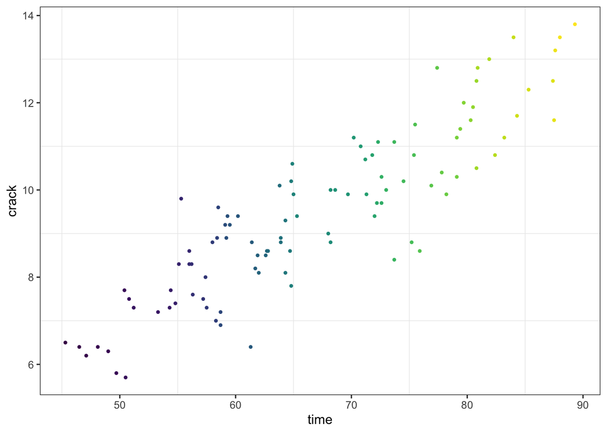

```r
wear_dat %>% ggplot(aes(time,wear,color = Unit)) +
  geom_line(size = 0.1) +
  geom_point(size = 0.8) +
  theme_bw() +
  theme(panel.grid.major = element_blank()) +
  scale_color_viridis(discrete = T) +
  theme(legend.position = 'none') +
  labs(x = "time", y = "crack")
```

#### 4.4.2 Crack of Titanium

```r
ti_dat = read.csv("dataset/Crack_Length_Data_of_Ten_Bar_of_Ti.csv")
knitr::kable(head(ti_dat))
```

| Unit | time | crack_length |
| --- | --- | --- |
| 1 | 5 | 92 |
| 1 | 10 | 218 |
| 1 | 15 | 311 |
| 1 | 20 | 410 |
| 1 | 25 | 507 |
| 1 | 30 | 605 |

```r
ti_dat$Unit = as.factor(ti_dat$Unit)
```

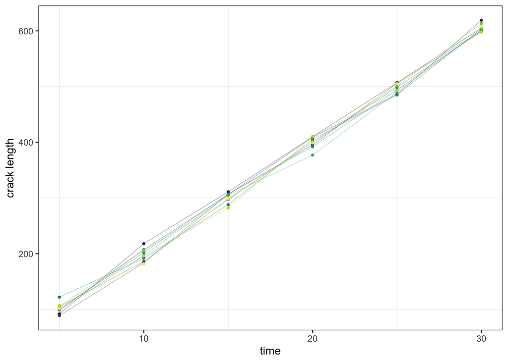

```r
ti_dat %>% ggplot(aes(time,crack_length,color = Unit)) +
  geom_line(size = 0.1) +
  geom_point(size = 0.8) +
  theme_bw() +
  theme(panel.grid.major = element_blank()) +
  scale_color_viridis(discrete = T) +
  theme(legend.position = 'none') +
  labs(x = "time", y = "crack length")
```

#### 4.4.3 Lithium-ion batteries

Lithium-ion batteries are widely used in many applications and consumer products including electric vehicles because of their high energy density and power capability. However, the long-term performance (capacity to provide the power) decreases with number of charge and discharge cycles. A degradation test is conducted on four battery cells with initial capacities in Ah (Ampere hours, which is defined as is the amount of energy charge in a battery that will allow one ampere of current to flow for one hour). The cells are discharged and charged, and the battery capacity is measured after the accumulation of a number of charge-discharge cycles. The battery is considered failed when its capacity is $80 \%$ of the original capacity. Use the first 25 observations of each cell and develop a general degradation model. Then utilize the model to predict the capacities at the remaining 17 cycles and calculate the error prediction of the models. Note that the original capacity corresponds to zero cycles.

```r
li_dat = read.csv("dataset/Lithium-ion batteries.csv")
knitr::kable(head(li_dat))
```

| cycles | Cell.1 | Cell.2 | Cell.3 | Cell.4 |
| --- | --- | --- | --- | --- |
| 0 | 2.543 | 2.532 | 2.525 | 2.496 |
| 150 | 2.497 | 2.495 | 2.487 | 2.466 |
| 300 | 2.466 | 2.467 | 2.463 | 2.438 |
| 450 | 2.453 | 2.452 | 2.447 | 2.435 |
| 600 | 2.428 | 2.424 | 2.412 | 2.399 |
| 750 | 2.400 | 2.400 | 2.393 | 2.376 |

```r
# ti_dat$Unit = as.factor(li_dat$Unit)
```

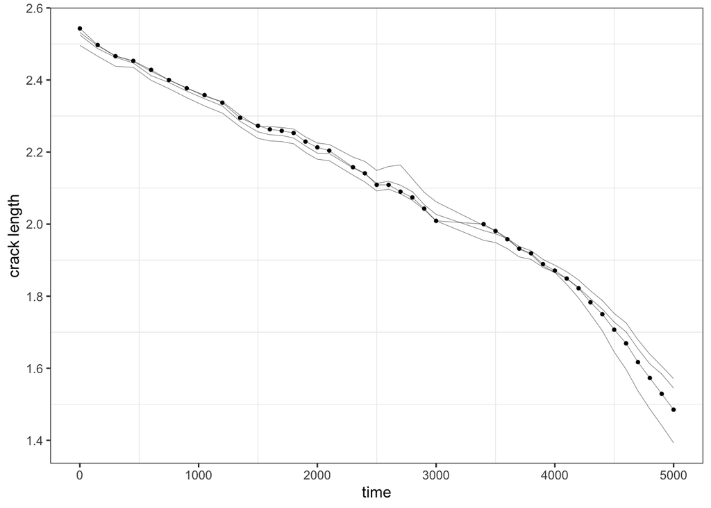

```r
li_dat %>% ggplot(aes(cycles,Cell.1,Cell.2,Cell.3,Cell.4)) +
  geom_line(aes(cycles,Cell.1),size = 0.1) +        geom_line(aes(cycles,Cell.2),size = 0.1) +
    geom_line(aes(cycles,Cell.3),size = 0.1) +   geom_line(aes(cycles,Cell.4),size = 0.1) +
  geom_point(size = 0.8) +
  theme_bw() +
  theme(panel.grid.major = element_blank()) +
  scale_color_viridis(discrete = T) +
  theme(legend.position = 'none') +
  labs(x = "time", y = "crack length")
```

#### 4.4.4 fatigue crack data

> 数据来自： Meeker, W. Q. (1998). Statistical Methods for Reliability Data

Fatigue Crack-Size Data gives the size of fatigue cracks as a function of number of cycles of applied stress for 21 test specimens. The data were collected to obtain information on crack growth rates for the alloy. Usually, we will refer to these data as Alloy-A and assume that a crack of size $1.6$ inches is considered to be a failure.

[figure not shown]

```r
fatigue_dat = read.csv("dataset/Fatigue Crack Growth Data.csv")
knitr::kable(head(fatigue_dat))
```

| path | cycles | crack |
| --- | --- | --- |
| 1 | 0 | 0.9 |
| 2 | 0 | 0.9 |
| 3 | 0 | 0.9 |
| 4 | 0 | 0.9 |
| 5 | 0 | 0.9 |
| 6 | 0 | 0.9 |

```r
fatigue_dat$path = as.factor(fatigue_dat$path)
```

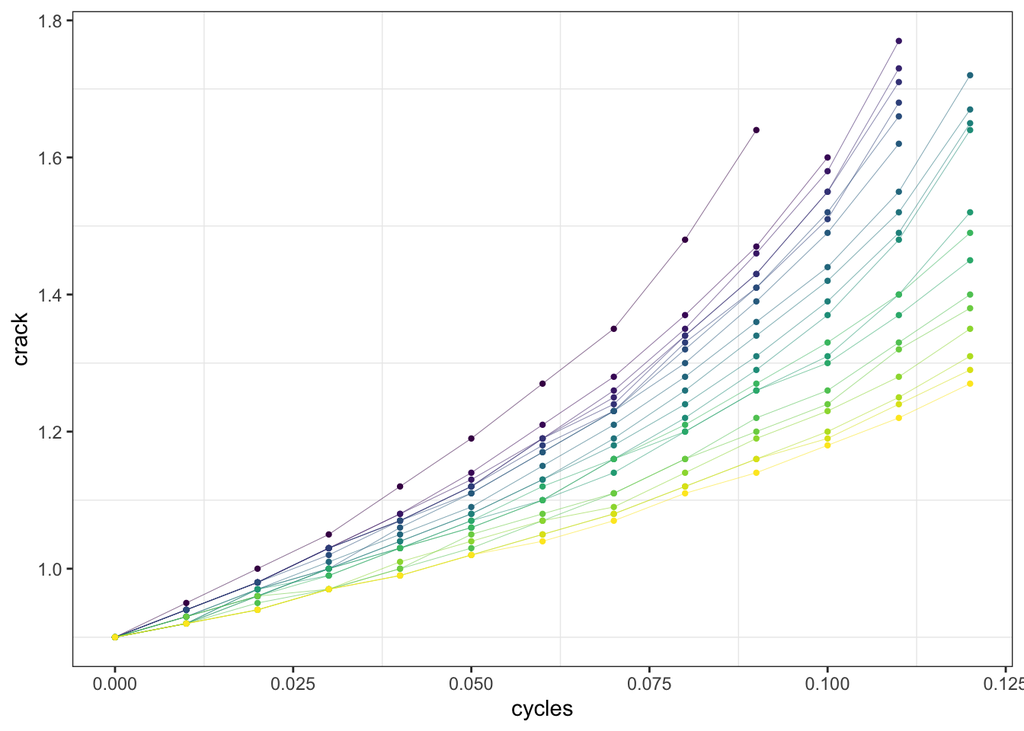

```r
fatigue_dat %>% ggplot(aes(cycles,crack,color = path)) +
  geom_line(size = 0.1) +
  geom_point(size = 0.8) +
  theme_bw() +
  theme(panel.grid.major = element_blank()) +
  scale_color_viridis(discrete = T) +
  theme(legend.position = 'none') +
  labs(x = "cycles", y = "crack")
```